# APLICACIÓN DE CLUSTER AGNES Y DIANA

Miguel Tesén

2025-02-02

##### Análisis de la Calidad de Vida en los Departamentos del Perú

El presente estudio tiene como objetivo analizar diversos indicadores socioeconómicos y de desarrollo en los departamentos del Perú, con el fin de comprender las diferencias en la calidad de vida a nivel regional. A través del análisis de tasas relacionadas con la educación, salud y acceso a servicios, se busca identificar patrones y desigualdades que permitan formular estrategias para mejorar las condiciones de vida de la población.

El acceso a la educación, la eficiencia en el sistema educativo, la conectividad a internet, la esperanza de vida y la tasa de mortalidad son algunas de las variables clave que se examinarán en este estudio. Mediante herramientas estadísticas y visualización de datos, se pretende ofrecer una visión integral de la situación actual y contribuir al diseño de políticas públicas más efectivas.

Para llevar a cabo este análisis, utilizaremos diversas librerías de R que facilitarán la manipulación, exploración y visualización de los datos.

#### DATA DEPARTAMENTOS

Es una base con todos los departamentos del Perú, sobre tasas y variables relacionadas a la calidad de vida. Las variables en estudio son las siguientes:

Variables en estudio

| VARIABLES | DESCRIPCIÓN |
| --- | --- |
| Departamento | Departamentos |
| Tinic | Tasa de educación inicial |
| Tprim | Tasa de educación primaria |
| Tsec | Tasa de educación secundaria |
| TDesn | Tasa de desnutrición |
| Tefic | Tasa de eficiencia educativa |
| Inter | Internet cada 100 habitantes |
| TAnalf | Tasa de analfabetismo |
| Tmort | Tasa de mortalidad |
| EVida | Esperanza de vida |

###### Librerías Necesarias

Antes de proceder con el análisis, cargamos las librerías necesarias para realizar el clustering jerárquico y visualizar los resultados.

```r
#------------------------------------------------------------------#
#                          Librerías necesarias                    #
#------------------------------------------------------------------#


library(cluster)
library(factoextra)
library(ggplot2)
library(dendextend)
library(NbClust)
library(igraph)
require(reshape2)
library(purrr)
library(data.table)
library(ecodist)
library(clValid)
library(dplyr)
```

##### ANÁLISIS CLUSTER JERÁRQUICO AGLOMERATIVO: AGNES

Carga y Exploración de los Datos Primero, cargamos los datos desde un archivo Excel y los inspeccionamos.

```r
#------------------------------------------------------------------#
#         1. ANÁLISIS CLUSTER JERÁRQUICOS AGLOMERATIVO             #
#------------------------------------------------------------------#
library(readxl)
Depar <- read_excel("Departamentos.xlsx")
Depar
```

```
## # A tibble: 23 × 10
##    Departamento Tinic Tprim  Tsec TDesn Tefic Inter TAnalf Tmort EVida
##    <chr>        <dbl> <dbl> <dbl> <dbl> <dbl> <dbl>  <dbl> <dbl> <dbl>
##  1 Junín         37.3  89.3  73.3  13.7  90.9   0.1   29.8  12.2  72.4
##  2 Piura         76    89.8  76.5   8.6  84.6   5.3   30.8  10.9  76.8
##  3 Pasco         50.8  89.6  62.5  25.9  83.5   0.3   31.1  11.1  69.8
##  4 Arequipa      63.2  93.1  81.8  20.2  83.1  13     22.7  10.9  76
##  5 Ayacucho      39.6  89.9  57.7  24.9  78.9   1.6   27.1  12.5  69.4
##  6 San Martín    40.5  92.8  57.9  17.1  83.4   4.2   25.9  12    75.3
##  7 Huánuco       24.9  89    48.6  14.3  86.8   1.8   29.5  11.3  74
##  8 Ancash        55.5  87.7  59.4  20.4  80.9   0.1   26.8  11.4  68.2
##  9 Ica           44.8  94.5  81.3   9.5  89.3   0.5   37.8  12.0  71
## 10 Tumbes        41.5  90.4  65.3  15.1  87.8   0.9   33.8  11.2  64.2
## # ℹ 13 more rows
```

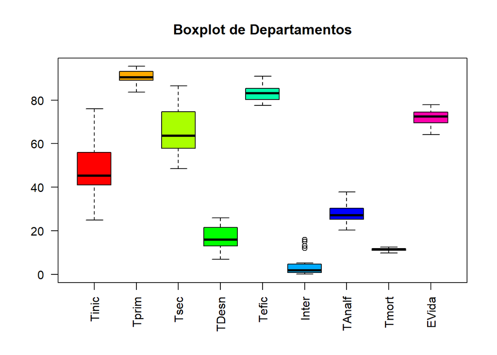

```r
Depar1 <- data.frame(Depar %>% select(-Departamento), row.names = Depar |> pull(Departamento))
boxplot(Depar1, col = rainbow(ncol(Depar1)), main = "Boxplot de Departamentos", las = 2)
```

##### Corrección de Valores Atípicos

Se detectaron valores atípicos en la variable Inter (Internet cada 100 habitantes), por lo que aplicamos una transformación para reducir su impacto.

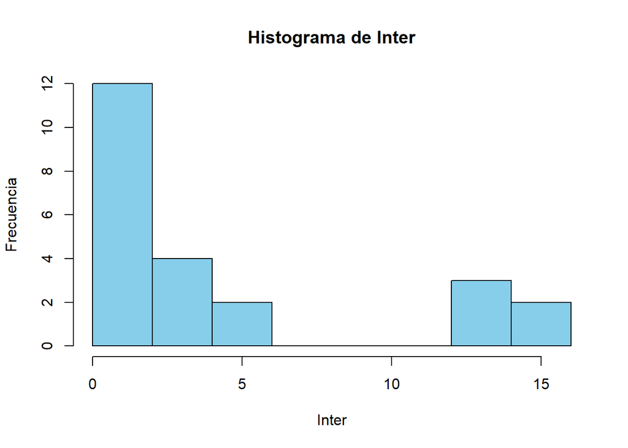

```r
#------------------------------------------------------------------#
#                  Corriengo el valor atípico                      #
#------------------------------------------------------------------#
Depar2<-Depar1
hist(Depar2$Inter, col = "skyblue", border = "black", main = "Histograma de Inter", xlab = "Inter", ylab = "Frecuencia")
```

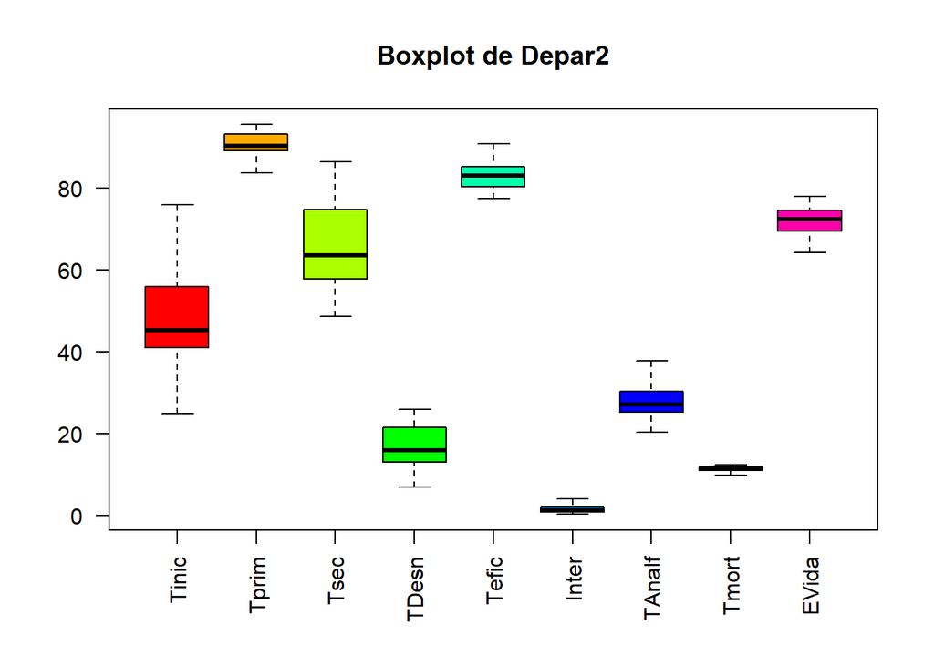

```r
Depar2$Inter<-sqrt(Depar2$Inter)
boxplot(Depar2, col = rainbow(ncol(Depar2)), main = "Boxplot de Depar2", las = 2)
```

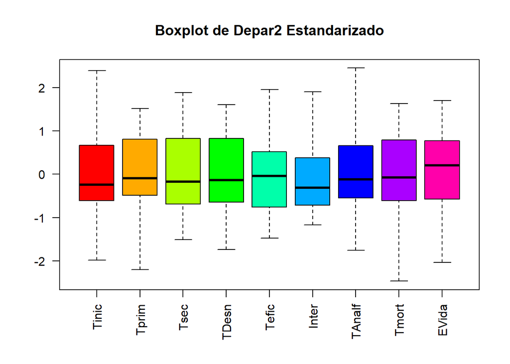

```r
boxplot(scale(Depar2), col = rainbow(ncol(Depar2)), main = "Boxplot de Depar2 Estandarizado", las = 2)
```

##### Cálculo de la Matriz de Distancias

El clustering jerárquico se basa en una matriz de distancias entre observaciones. Utilizamos la distancia euclidiana después de estandarizar las variable

```r
#------------------------------------------------------------------#
#                 Hallando la matriz de distancias                 #
#------------------------------------------------------------------#
dist <- daisy(scale(Depar2), metric = "euclidean")
```

##### Aplicación del Método de Enlace Ward

Se aplica el método de clustering jerárquico utilizando el criterio de enlace de Ward, que minimiza la varianza dentro de los clusters.

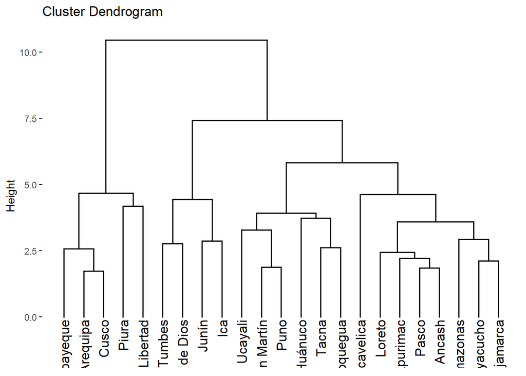

```r
#------------------------------------------------------------------#
#                     Cluster enlace ward                          #
#------------------------------------------------------------------#
Clus4 <- hclust(dist,method="ward.D2")
fviz_dend(Clus4, cex = 0.9)
```

###### Selección del Número Óptimo de Clusters

Para determinar la cantidad ideal de clusters, utilizamos el criterio de NbClust, que evalúa múltiples índices.

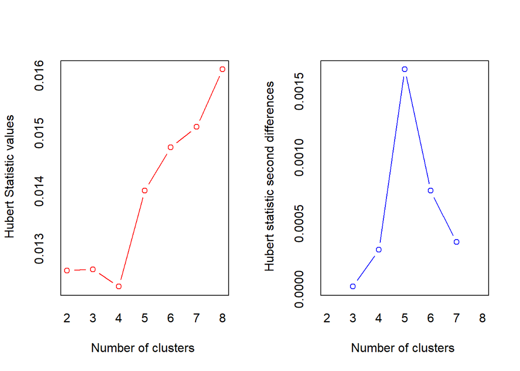

```
## *** : The Hubert index is a graphical method of determining the number of clusters.
##                 In the plot of Hubert index, we seek a significant knee that corresponds to a
##                 significant increase of the value of the measure i.e the significant peak in Hubert
##                 index second differences plot.
##
```

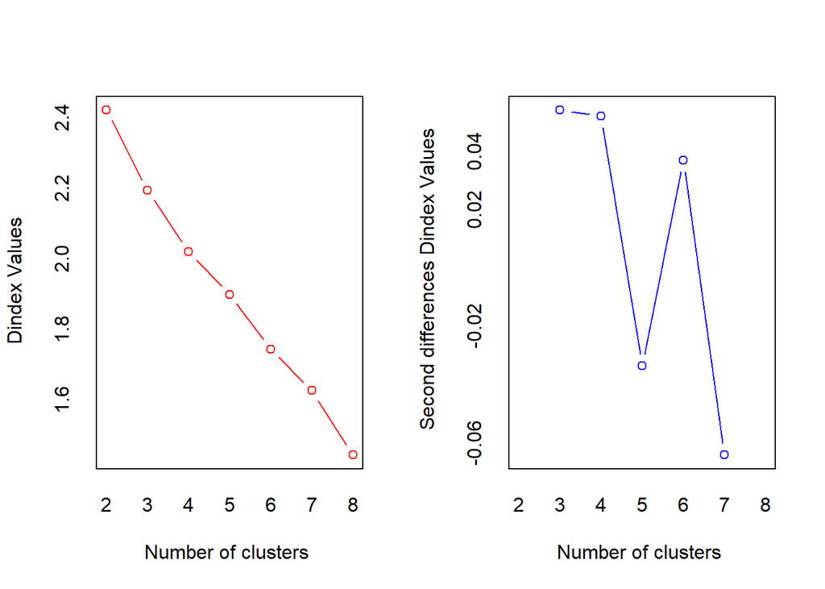

```
## *** : The D index is a graphical method of determining the number of clusters.
##                 In the plot of D index, we seek a significant knee (the significant peak in Dindex
##                 second differences plot) that corresponds to a significant increase of the value of
##                 the measure.
##
## * Among all indices:
## * 8 proposed 2 as the best number of clusters
## * 9 proposed 3 as the best number of clusters
## * 1 proposed 4 as the best number of clusters
## * 1 proposed 6 as the best number of clusters
## * 2 proposed 7 as the best number of clusters
## * 6 proposed 8 as the best number of clusters
##
##                    ***** Conclusion *****
##
## * According to the majority rule, the best number of clusters is  3
##
##
```

```r
#------------------------------------------------------------------#
#                     Eligiendo número de cluster                  #
#------------------------------------------------------------------#

Nclus <- NbClust(scale(Depar2), distance = "euclidean", min.nc = 2, max.nc = 8,method = "ward.D2", index = "alllong")
```

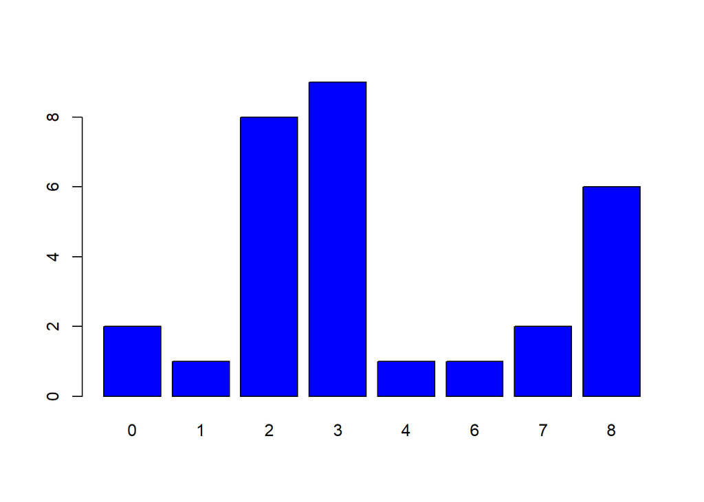

```r
par(mfrow=c(1,1))
barplot(table(t(Nclus$Best.nc)[,1]),col = "blue")
```

##### Visualización de los Clusters

Se genera el dendrograma con los clusters coloreados y delimitados.

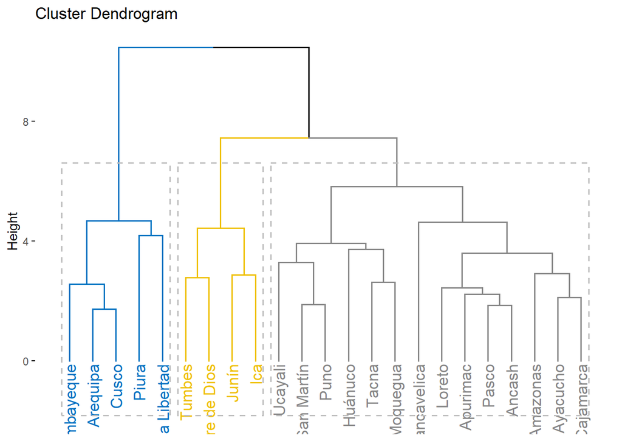

```r
#------------------------------------------------------------------#
#                     Visualización de clusters                    #
#------------------------------------------------------------------#

# corte en 3 grupos y colores por grupos
fviz_dend(Clus4, k = 3, # corte en 3 grupos
          cex = 0.9, # tamaño de etiqueta
          k_colors ="jco",
          color_labels_by_k = TRUE, # color etiqueta por grupo
          rect = TRUE) # añadir rectángulo al rededor de los grupos
```

###### Caracterización de los Clusters

Para interpretar los resultados, analizamos las características de cada grupo.

```r
#------------------------------------------------------------------#
#               Características de lo clusters                     #
#------------------------------------------------------------------#
# Cortando en 3 cluester
# ----------------------
grp=cutree(Clus4, k = 3)



# Number de casos en cada cluster
# -------------------------------
table(grp)
```

```
## grp
##  1  2  3
##  4  5 14
```

```r
cbind(Depar1, grp)
```

```
##               Tinic Tprim Tsec TDesn Tefic Inter TAnalf Tmort EVida grp
## Junín          37.3  89.3 73.3  13.7  90.9   0.1  29.83 12.16 72.40   1
## Piura          76.0  89.8 76.5   8.6  84.6   5.3  30.77 10.91 76.80   2
## Pasco          50.8  89.6 62.5  25.9  83.5   0.3  31.10 11.10 69.80   3
## Arequipa       63.2  93.1 81.8  20.2  83.1  13.0  22.71 10.91 76.00   2
## Ayacucho       39.6  89.9 57.7  24.9  78.9   1.6  27.13 12.46 69.40   3
## San Martín     40.5  92.8 57.9  17.1  83.4   4.2  25.94 12.00 75.30   3
## Huánuco        24.9  89.0 48.6  14.3  86.8   1.8  29.46 11.34 74.00   3
## Ancash         55.5  87.7 59.4  20.4  80.9   0.1  26.81 11.36 68.20   3
## Ica            44.8  94.5 81.3   9.5  89.3   0.5  37.76 12.03 71.00   1
## Tumbes         41.5  90.4 65.3  15.1  87.8   0.9  33.77 11.18 64.20   1
## Ucayali        56.4  91.4 67.9  10.0  77.5   1.4  32.40 11.84 70.90   3
## Cusco          59.6  94.1 86.5  16.0  78.8  13.1  22.68 11.15 72.80   2
## Cajamarca      41.6  90.0 50.0  20.9  80.5   2.1  32.27 11.65 67.90   3
## Lambayeque     45.2  94.2 72.6  20.5  85.3  12.1  25.29 10.86 75.20   2
## Apurimac       45.3  88.8 63.6  22.6  79.0   0.8  27.57 10.27 68.30   3
## Madre de Dios  40.3  95.5 76.1  14.4  83.1   2.6  27.53 10.93 64.40   1
## Amazonas       46.0  83.7 55.1  22.1  80.5   3.7  24.82 11.58 69.90   3
## Tacna          43.2  87.1 58.7   9.2  81.9   0.3  27.08 12.05 69.70   3
## Puno           50.4  93.4 69.3  15.1  84.0   0.7  26.25 11.70 73.10   3
## Huancavelica   28.6  90.7 50.1  23.6  79.0  15.0  21.82 11.65 72.80   3
## Moquegua       57.2  84.2 61.5  12.5  85.3   3.2  25.29 12.29 75.00   3
## La Libertad    63.2  94.7 77.3   6.9  90.8  16.0  20.28  9.82 77.90   2
## Loreto         55.0  91.8 52.6  22.5  80.1   0.9  25.61 11.17 73.08   3
```

```r
# Descripción de cada cluster
# -------------------------------
med<-round(aggregate(Depar1, by=list(cluster=grp), mean),3)
med
```

```
##   cluster  Tinic  Tprim   Tsec  TDesn  Tefic  Inter TAnalf  Tmort  EVida
## 1       1 40.975 92.425 74.000 13.175 87.775  1.025 32.222 11.575 68.000
## 2       2 61.440 93.180 78.940 14.440 84.520 11.900 24.346 10.730 75.740
## 3       3 45.357 89.293 58.207 18.650 81.521  2.579 27.396 11.604 71.241
```

Conclusión: A partir del análisis de clustering jerárquico aplicado a los departamentos del Perú, se identificaron tres grupos con características distintas en cuanto a indicadores de calidad de vida.

##### ANÁLISIS CLUSTER JERÁRQUICO Divisivo: DIANA

1. Aplicación del Algoritmo DIANA

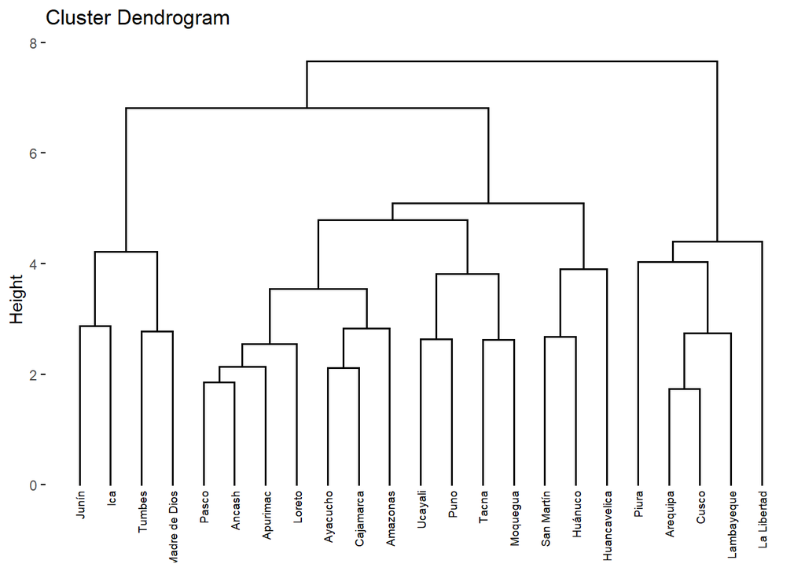

```r
#------------------------------------------------------------------#
#                         Algoritmo DIANA                          #
#------------------------------------------------------------------#
Clus5=as.hclust(diana(scale(Depar2)))
fviz_dend(Clus5, cex = 0.5)
```

🔹 Se aplica el algoritmo DIANA (Divisive Analysis Clustering), un método de clustering jerárquico divisivo.

🔹 Se genera un dendrograma para visualizar cómo se forman los grupos de departamentos.

2. Índice Divisivo

```r
# índice divisivo
# ---------------
coef(Clus5)
```

```
## [1] 0.6530265
```

🔹 Se obtiene el coeficiente divisivo, que mide la estructura jerárquica de los clusters.

🔹 Un valor más alto indica una separación más clara entre los grupos.

3. Selección del Número Óptimo de Clusters

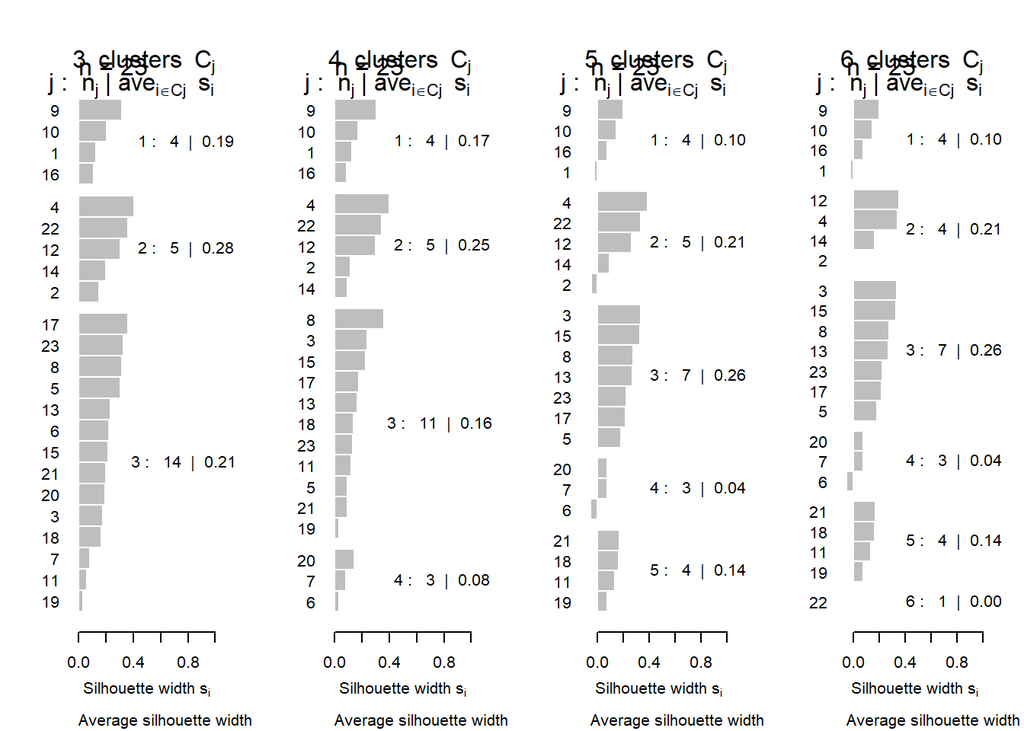

```r
# Sugerencia Número de Cluster
# ----------------------------
# Gráfica de silueta
# ----------------------------
Depar2<-Depar1
dist.depar=daisy(scale(Depar2))
par(mfrow=c(1,4))
for(h in 3:6){
  conglomerados=cutree(Clus5,h)
  plot(silhouette(conglomerados,dist.depar),main = "")
}
```

🔹 Se evalúan diferentes cortes del dendrograma (de 3 a 6 clusters) mediante gráficos de índices de silueta, que ayudan a determinar cuán bien estructurados están los grupos.

4. Visualización de los Clusters

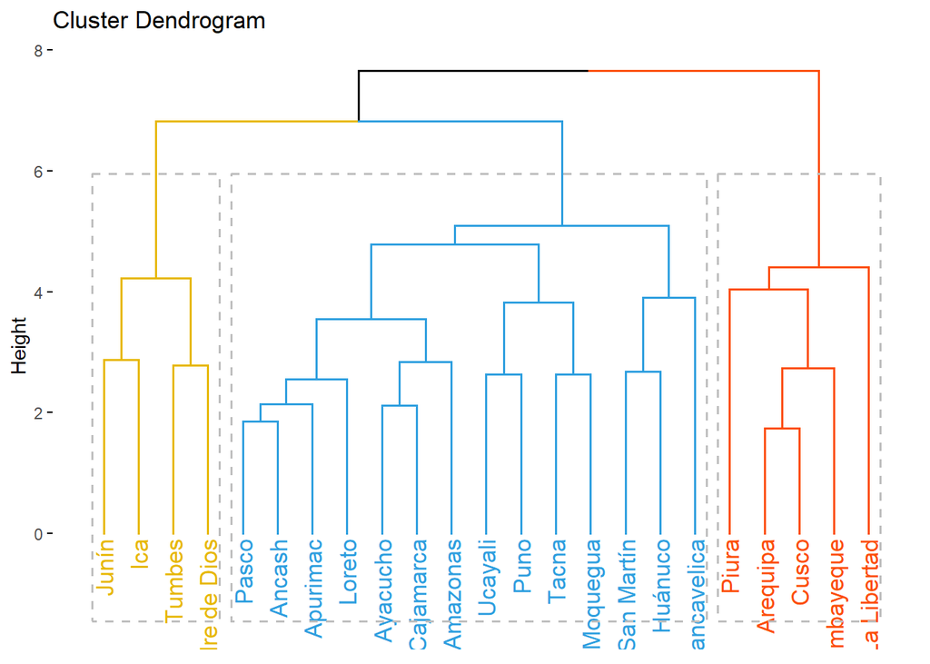

```r
# corte en 3 grupos y colores por grupos
fviz_dend(Clus5, k = 3, # corte en 3 grupos
          cex = 0.9, # tamaño de etiqueta
          k_colors = c(  "#E7B800", "#2E9FDF","#FC4E07"),
          color_labels_by_k = TRUE, # color etiqueta por grupo
          rect = TRUE) # añadir rectángulo al rededor de los grupos
```

🔹 Se selecciona 3 clusters y se colorean en el dendrograma para una mejor interpretación.

🔹 Se agregan rectángulos alrededor de los grupos para delimitar las categorías visualmente

5. Análisis de los Clusters Formados

```r
# Cortando en 3 cluster
# ----------------------
grp2=cutree(Clus5, k = 3)

# Number de casos en cada cluster
# -------------------------------
table(grp2)
```

```
## grp2
##  1  2  3
##  4  5 14
```

🔹 Se genera una variable (grp2) que asigna a cada departamento un grupo específico.

🔹 Se obtiene el número de departamentos en cada cluster.

6. Caracterización de los Clusters

```r
# Descripción de cada cluster
# -------------------------------
med2<-round(aggregate(Depar1, by=list(cluster=grp2), mean),3)
med2
```

```
##   cluster  Tinic  Tprim   Tsec  TDesn  Tefic  Inter TAnalf  Tmort  EVida
## 1       1 40.975 92.425 74.000 13.175 87.775  1.025 32.222 11.575 68.000
## 2       2 61.440 93.180 78.940 14.440 84.520 11.900 24.346 10.730 75.740
## 3       3 45.357 89.293 58.207 18.650 81.521  2.579 27.396 11.604 71.241
```

🔹 Se calcula la media de cada variable por cluster para interpretar las diferencias entre los grupos.

🔹 Esto permite identificar patrones en las tasas de educación, desnutrición, mortalidad y acceso a internet.

Conclusiones Generales

📌 Se aplicó el algoritmo DIANA para realizar un análisis de clustering jerárquico divisivo, agrupando los departamentos del Perú en base a variables de calidad de vida.

📌 Se determinó que el número óptimo de clusters es 3, basándose en índices de silueta y el dendrograma generado.

📌 Cada cluster presenta características distintas, reflejando diferencias en tasas de educación, mortalidad, desnutrición y acceso a internet.

📌 El análisis de la media de cada cluster permitió identificar patrones en la calidad de vida entre los departamentos agrupados.

🔹 Este análisis es útil para estudios de políticas públicas, ya que permite segmentar los departamentos según sus características y enfocar esfuerzos en mejorar su calidad de vida